# BIOSTAT 830 Problem Set 3 Solutions

8). *Posterior predictive checking*

```r
new_Y_samp <- array(get_res("new_Y",res),c(nrow(res),N,K))

logOR_pred <- array(NA,c(K,K,nrow(res)))

# at each iteration, calculate the predicted log odds ratios for each pair of symptoms:
for (iter in 1:nrow(res)){
  for (i in 1:K){
    for (j in 1:K){
      if (i!=j){
        logOR_pred[i,j,iter] <- lor_obs(new_Y_samp[iter,,i],new_Y_samp[iter,,j])
      }
    }
  }
}
```

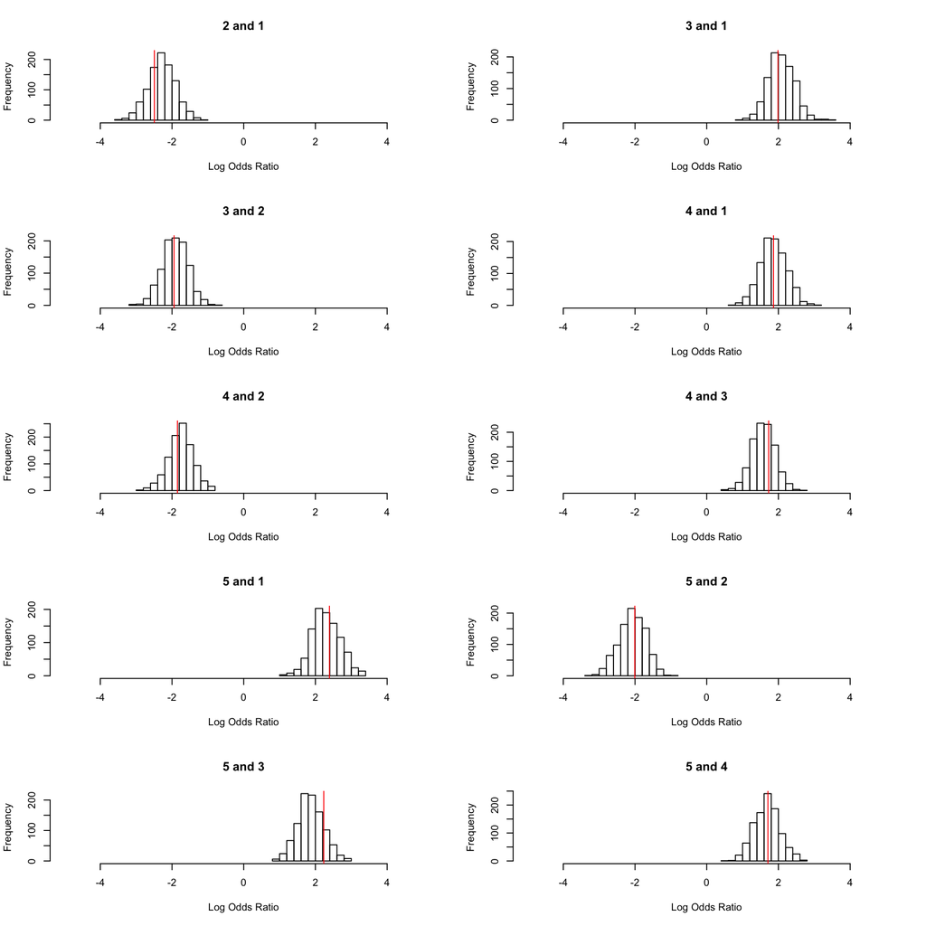

Model-based posterior predictive distributions for pairwise log odds ratios, one for each pair of symptoms. For each subfigure, the observed log odds ratio for that pair of symptoms is shown as the red vertical line.

```r
# visualize the posterior predictive distribution and the observed values:
par(mfrow=c(5,2))
for (i in 2:K){
  for (j in 1:(i-1)){
    hist(logOR_pred[i,j,],xlim=c(-5,5), xlab="Log Odds Ratio", main=paste0(i," and ", j))
    abline(v=psi_obs_mat[i,j],col="red")
  }
}
```

9). *Repeat the analyses with different class numbers*

This solution presents results of the posterior predictive checking for pariwise log odds ratios. An analyst can try different numbers of latent classes and needs to either decide the number of latent classes for later analyses or incorporate its uncertainty. The `R` code below fits the simulated data to a model with $M_{fit}=2$ latent classes. We can similarly obtain the posterior samples from the `JAGS` outputs and then use them to visualize the posterior distributions of the unknown parameters.

```r
result_folder2 <- file.path(tempdir(),"Mfit2")
dir.create(result_folder2)
# write .bug model file:
model_bugfile_name <- "model.bug"
filename2   <- file.path(result_folder2, model_bugfile_name)
writeLines(model_text, filename2)

M_fit <- 2
in_init <- function(){
  list(a=rep(0,M_fit-1))
}
out <- R2jags::jags2(data   = in_data,
                    inits   = in_init,
                    parameters.to.save = out_parameter,
                    model.file = filename,
                    working.directory = result_folder2,
                    n.iter         = as.integer(mcmc_options$n.itermcmc),
                    n.burnin       = as.integer(mcmc_options$n.burnin),
                    n.thin         = as.integer(mcmc_options$n.thin),
                    n.chains       = as.integer(mcmc_options$n.chains),
                    DIC            = FALSE,
                    clearWD        = FALSE)

# obtain the chain histories:
res2 <- coda::read.coda(file.path(result_folder2,"CODAchain1.txt"),
                        file.path(result_folder2,"CODAindex.txt"),
                        quiet=TRUE)
```

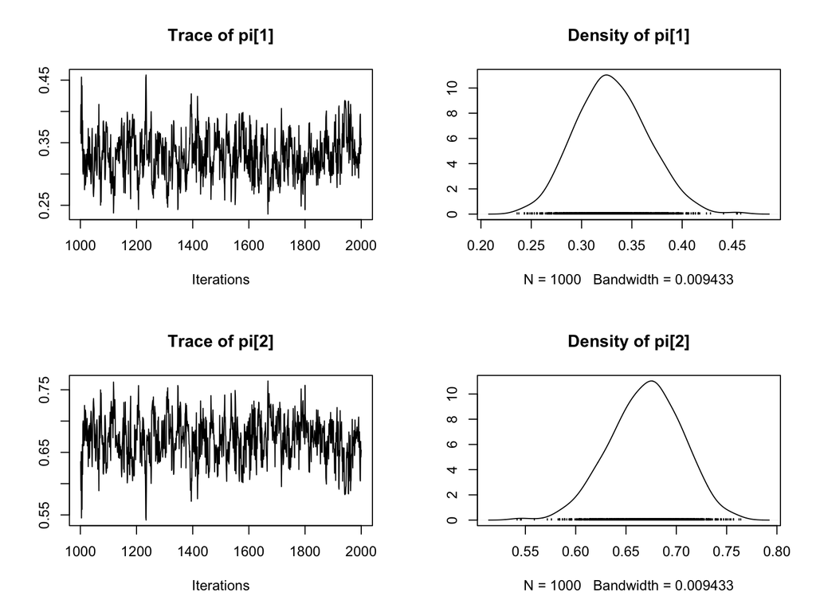

Chain histories for the two class probabilities

```r
print_res("pi",res2)
```

```r
new_Y_samp2 <- array(get_res("new_Y",res2),c(nrow(res2),N,K))
logOR_pred2 <- array(NA,c(K,K,nrow(res2)))

# at each iteration, calculate the predicted log odds ratios for each pair of symptoms:
for (iter in 1:nrow(res2)){
  for (i in 1:K){
    for (j in 1:K){
      if (i!=j){
        logOR_pred2[i,j,iter] <- lor_obs(new_Y_samp2[iter,,i],new_Y_samp2[iter,,j])
      }
    }
  }
}
```

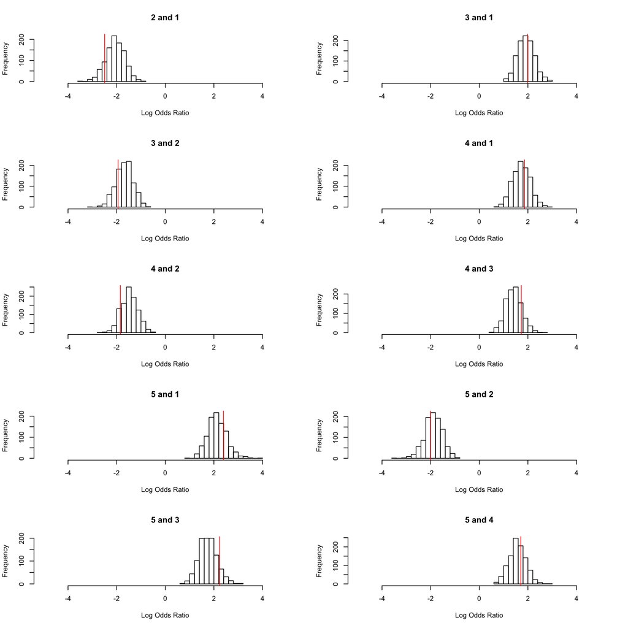

Two-class posterior predictive distributions for pairwise log odds ratios, one for each pair of symptoms. For each subfigure, the observed log odds ratio for that pair of symptoms is shown as the red vertical line.

```r
# visualize the posterior predictive distribution and the observed values:
par(mfrow=c(5,2))
for (i in 2:K){
  for (j in 1:(i-1)){
    hist(logOR_pred2[i,j,],xlim=c(-5,5), xlab="Log Odds Ratio", main=paste0(i," and ", j))
    abline(v=psi_obs_mat[i,j],col="red")
  }
}
```

We then fit the data with $M_{fit}=4$ latent class model. Below are two figures similar to the ones obtained for $M_{fit}=2,3$.

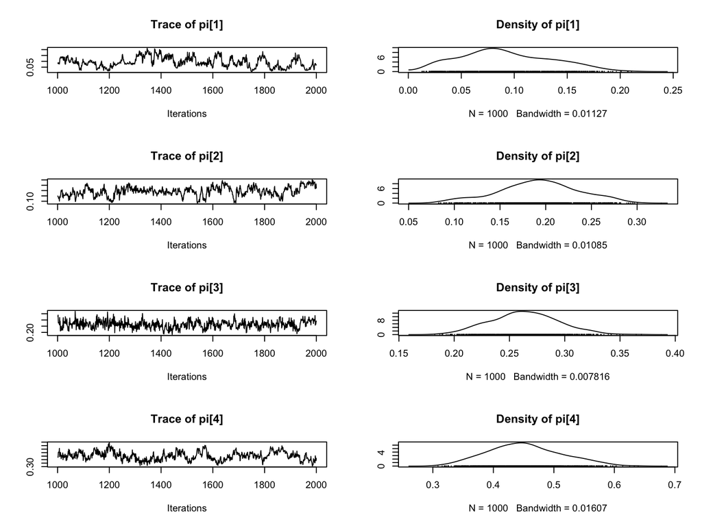

Chain histories for the four class probabilities

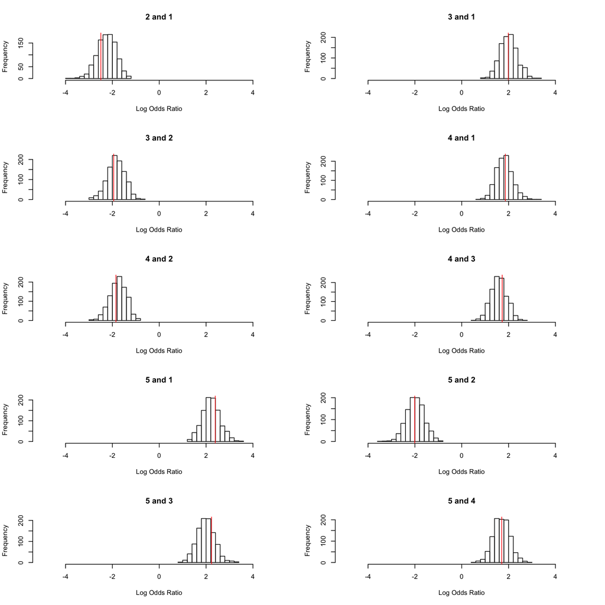

Four-class posterior predictive distributions for pairwise log odds ratios, one for each pair of symptoms. For each subfigure, the observed log odds ratio for that pair of symptoms is shown as the red vertical line.

In general, such posterior predictive checking is useful for model diagnostics. At each iteration of the MCMC chain, we generate a hypothetical data set according to the model at the the current parameter values. If large discrepancies exist for the generated versus the actual data sets with respect to observables (e.g. log odds ratio), they indicate that the current model is inadequate to capture certain asepcts of the data and can be improved.

10). *Summarize your experience* (Below is a non-exhaustive list.)

1. The dependence between two symptoms, $k$ and $k'$ is induced by their respective associations with the unobserved latent depression class indicator $\eta_i$ (see the DAG in the first question).
2. A small number of latent classes constrain the model space but could not fully account for the multivariate dependence observed in the data. Extra latent classes can describe the observed associations but require extra parameters for ${p_{jk}}$ and $\boldsymbol{\pi}$. In practice, we usually strike a balance between model parsimony (a simple model capable of describing important features of the data, e.g., the pairwise log odds ratios) and the size of the model space.